# A3 INFO 201

Zacharia Kornas

[Link to website](https://info-201a-wi22.github.io/a3-zkornas/)

# Problem Domain:

### Understanding racial injustice in American Incarceration

In the last ten years Americans have begun to look critically at the justice system in our country. The clear pattern of racial injustice and continued systematic oppression of minorities, specifically African Americans, has been discussed in mainstream media. The data analyzed in this report and sourced by *Vera, Institute of Justice* shows just how severe the systematic oppression of minority groups in the USA is. In this report, we will analyze the data and uncover trends of how different racial groups in the United States are threatened by incarceration.

### Values of interest

**Value One:** Out of all the counties in the United States, which have the largest incarcerated population by race? - Black: 5024 (hundreds), Los Angeles County, CA

- White: 4577 (hundreds), Maricopa County, AZ
- Latinx: 8728 (hundreds), Los Angeles County, CA
- Asian and Pacific Islander: 286.4 (hundreds), San Bernardino County, CA
- Native: 379 (hundreds), Pennington County, SD
- Other: 608 (hundreds), Los Angeles County, CA

I decided to look at these values to give me a sense of where specific racial groups may be facing the most systematic oppression in the country.

**Value Two:** Out of all the counties, which have the highest ratio of incarcerated vs total population of both black and white populations?

- Black: 3, Daggett County, UT
- White: 0.7388749, East Carroll Parish, LA

I chose to look at these variables as it is known that African Americans are at higher risk of incarceration in the United States compared to Caucasians, and this variable allows me to see where both African Americans and Caucasians are targeted by the prison system the most, and to what severity, in the United States.

**Value Three:** In the most recently recorded year, what is the average ratio of incarcerated black and white populations vs total racial population in a region?

- Black: 0.0251929
- White: 0.0049813

I wanted to look at the average ratio of incarceration by race across the USA to get an understanding of how African American communities are impacted compared to that of Caucasian communities. This will hopefully provide some insight into the extent of the issue we are facing.

**Value Four:** In the most recently recorded year, what is the percent of black and white populations incarcerated vs total racial population in King County, Washington?

- Black: In King County, African Americans make up 7.3269522% of the population and 30.8480392% of the the incarcerated population.
- White: In King County, White people make up 60.5467852% of the population and 51.1542484% of the incarcerated population.

I specifically wanted to look at this issue in the context of King County, as this is where we live. I think seeing the rate of incarcerated African Americans compared to Caucasians in an area we see as liberal and progressive shows us how deeply ingrained this issue is, in our society.

**Value Five:** In the earliest recorded year, what is percent of the total population of King County was made up of African Americans vs Caucasians? What percent of the incarcerated population in the same year was made up of African Americans vs Caucasians?

- Black: In the earliest recorded year, African Americans made up 4.7099145% of the total population and 33.2930806% of the incarcerated population.
- White: In the earliest recorded year, Caucasians made up 83.5061945% of the total population and 49.0797921% of the incarcerated population.

After looking at the most recent data in King County, I wanted to see how incarceration rates changed from the past. I looked at the earliest recorded year, 1990, and will hopefully be able to see if the trend in incarceration by racial communities is increasing, decreasing, or remaining the same.

### Graphs

**Graph 1:** Number of White and Black incarcerated peoples in King County from 1990 to 2018

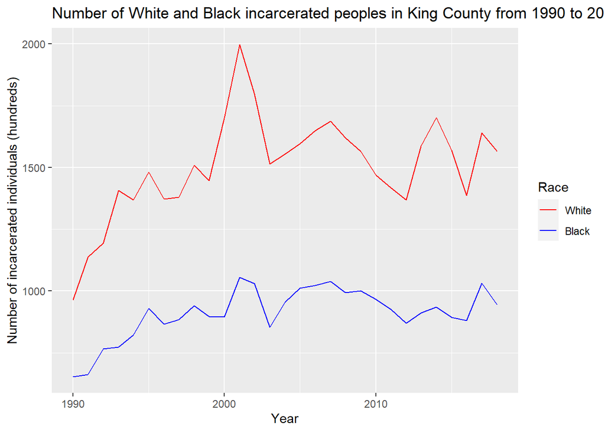

**Graph 2:** Ratio of incarcerated individuals to total racial population by race in King County 2018

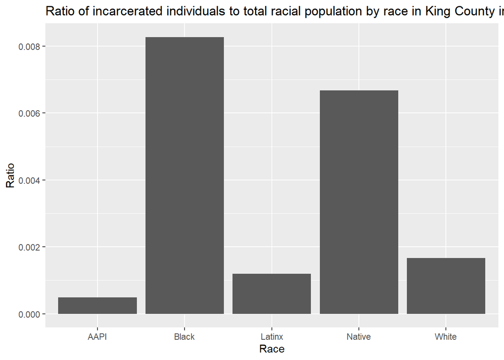

**Graph 3:** Map of ratio of incarcerated African Americans to total African American population by county in 2018

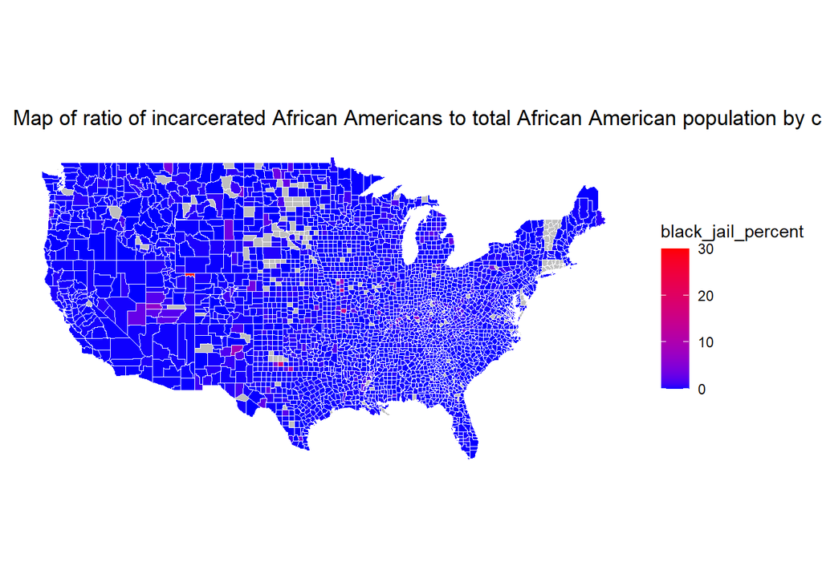